# Linear Regression

### Linear Regression on GDP dataset

The site Gapminder compiled a dataset with population, life expectancy and GDP per capita of 142 countries over 12 years. Let us analyze the data.

Importing data:

```r
gdp = read.csv2("C:\\Users\\dougl\\Documents\\DOUGLAS\\Data_Scientist\\data\\gdp_gapminder.csv", sep = ",", header = TRUE)
```

Checking the data structure:

```r
str(gdp)
```

```
## 'data.frame':    1704 obs. of  6 variables:
##  $ country  : chr  "Afghanistan" "Afghanistan" "Afghanistan" "Afghanistan" ...
##  $ year     : int  1952 1957 1962 1967 1972 1977 1982 1987 1992 1997 ...
##  $ pop      : chr  "8425333" "9240934" "10267083" "11537966" ...
##  $ continent: chr  "Asia" "Asia" "Asia" "Asia" ...
##  $ expLife  : chr  "28.801" "30.332" "31.997" "34.02" ...
##  $ gdpPercap: chr  "779.4453145" "820.8530296" "853.10071" "836.1971382" ...
```

```r
library(dplyr)
gdp = gdp %>% mutate(pop = as.double(pop), expLife = as.integer(expLife), gdpPercap = as.numeric(gdpPercap))
```

Data summary:

```r
summary(gdp)
```

```
##    country               year           pop             continent
##  Length:1704        Min.   :1952   Min.   :6.001e+04   Length:1704
##  Class :character   1st Qu.:1966   1st Qu.:2.794e+06   Class :character
##  Mode  :character   Median :1980   Median :7.024e+06   Mode  :character
##                     Mean   :1980   Mean   :2.960e+07
##                     3rd Qu.:1993   3rd Qu.:1.959e+07
##                     Max.   :2007   Max.   :1.319e+09
##     expLife        gdpPercap
##  Min.   :23.00   Min.   :   241.2
##  1st Qu.:48.00   1st Qu.:  1202.1
##  Median :60.00   Median :  3531.8
##  Mean   :58.97   Mean   :  7215.3
##  3rd Qu.:70.00   3rd Qu.:  9325.5
##  Max.   :82.00   Max.   :113523.1
```

Tables with absolute and relative frequency of observations per continent:

```
i) Absolute frequency
```

```r
cont_abs <- data.frame(table(gdp$continent))
cont_abs
```

```
##       Var1 Freq
## 1   Africa  624
## 2 Americas  300
## 3     Asia  396
## 4   Europe  360
## 5  Oceania   24
```

```
ii) Relative frequency
```

```r
cont_rel <- data.frame(round(table(gdp$continent)/length(gdp$continent),2)*100)
cont_rel
```

```
##       Var1 Freq
## 1   Africa   37
## 2 Americas   18
## 3     Asia   23
## 4   Europe   21
## 5  Oceania    1
```

Bar chart with absolute frequency of continents:

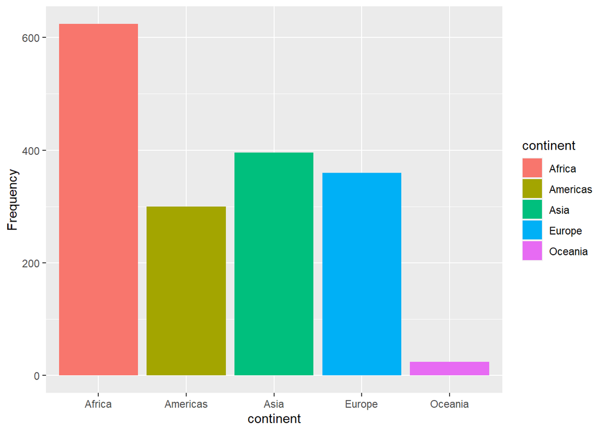

```r
library(ggplot2)
library(ggpubr)
ggplot(gdp, aes(x=continent, fill=continent)) + geom_bar() + ylab("Frequency")
```

Graph correlating GDP per capita with life expectancy:

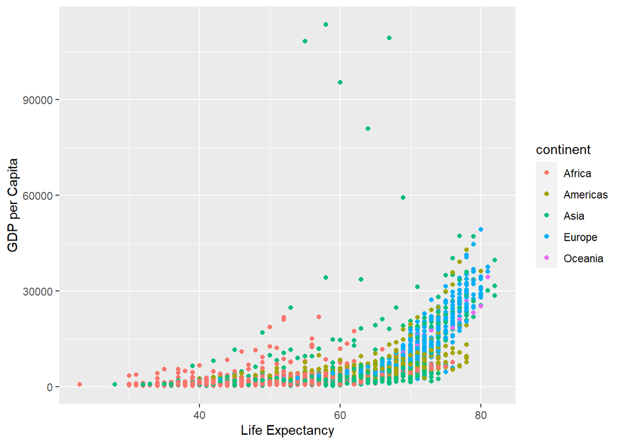

```r
g <- ggplot(data = gdp, aes(x = expLife, y = gdpPercap, color = continent)) + geom_point() + labs(x = "Life Expectancy", y = "GDP per Capita")
g
```

Creating 2 new columns in the same dataset with log of GDP per capita and log of Life expectancy:

```r
library(plm)
lgdpPercap <- log(gdp$gdpPercap)
lexpLife <- log(gdp$expLife)
gdp["lgdpPercap"] <- lgdpPercap
gdp["lexpLife"] <- lexpLife
str(gdp)
```

```
## 'data.frame':    1704 obs. of  8 variables:
##  $ country   : chr  "Afghanistan" "Afghanistan" "Afghanistan" "Afghanistan" ...
##  $ year      : int  1952 1957 1962 1967 1972 1977 1982 1987 1992 1997 ...
##  $ pop       : num  8425333 9240934 10267083 11537966 13079460 ...
##  $ continent : chr  "Asia" "Asia" "Asia" "Asia" ...
##  $ expLife   : int  28 30 31 34 36 38 39 40 41 41 ...
##  $ gdpPercap : num  779 821 853 836 740 ...
##  $ lgdpPercap: num  6.66 6.71 6.75 6.73 6.61 ...
##  $ lexpLife  : num  3.33 3.4 3.43 3.53 3.58 ...
```

Graph correlating these 2 new attributes:

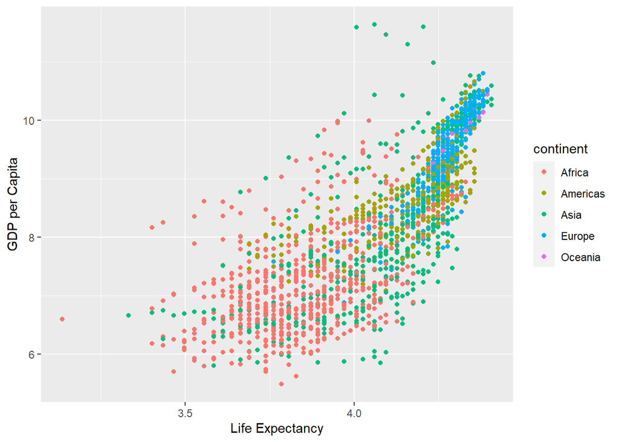

```r
g <- ggplot(data = gdp, aes(x = lexpLife, y = lgdpPercap, color = continent)) + geom_point() + labs(x = "Life Expectancy", y = "GDP per Capita")
g
```

Adjusting a linear model to data by using these 2 new attributes and being lexpLife the dependent variable:

```r
X <- gdp$lgdpPercap
Y <- gdp$lexpLife

model <- lm(Y ~ X, gdp)
model
```

```
##
## Call:
## lm(formula = Y ~ X, data = gdp)
##
## Coefficients:
## (Intercept)            X
##      2.8446       0.1478
```

Performing the regression analysis:

```
i)   Diagnosing graphics
```

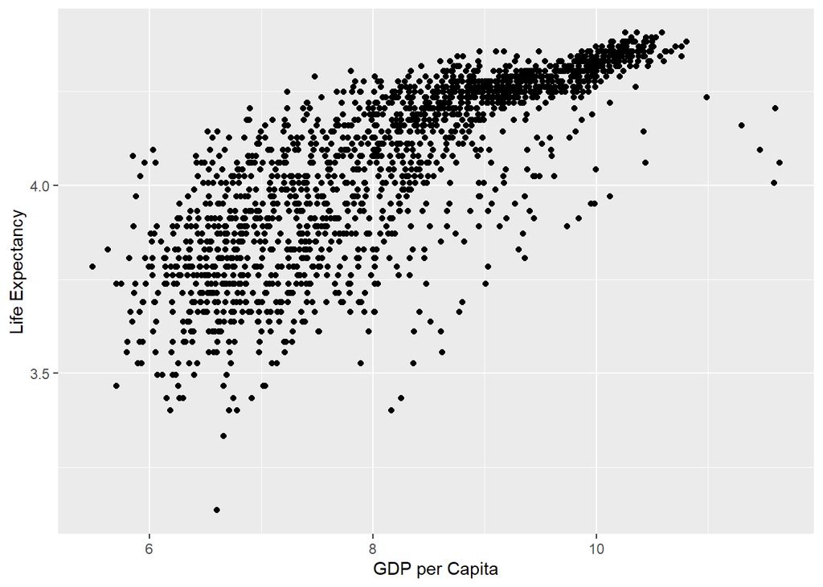

```r
g <- ggplot(data = gdp, aes(x = X, y = Y)) + geom_point() + xlab("GDP per Capita") + ylab("Life Expectancy")
g
```

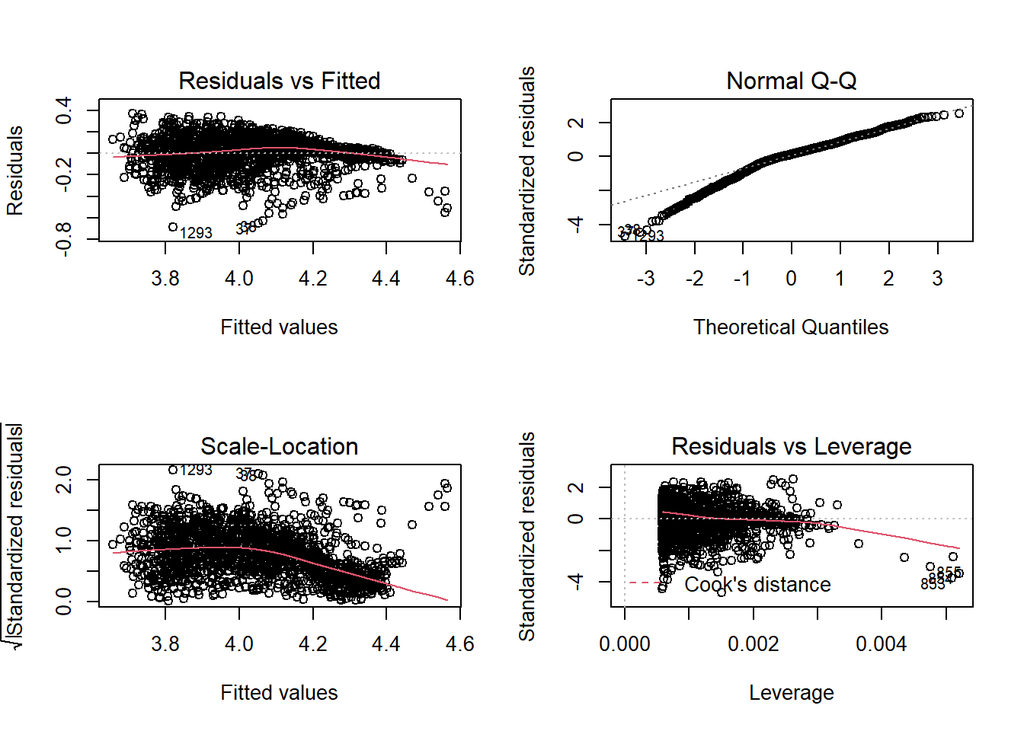

```r
par(mfrow=c(2,2))
plot(model)
```

As per the scatter plots we can see a correlation between life expectancy and GDP per capita but there is no clear linearity.

In the residual x fitted values graph there is a certain residual concentration and a decrease of the same as the adjusted values increase. We can also see that residuals do not follow a normal distribution on Normal Q-Q graph.

```
ii) Evaluate model summary
```

```r
summary(model)
```

```
##
## Call:
## lm(formula = Y ~ X, data = gdp)
##
## Residuals:
##      Min       1Q   Median       3Q      Max
## -0.68523 -0.06512  0.01951  0.09147  0.36819
##
## Coefficients:
##             Estimate Std. Error t value Pr(>|t|)
## (Intercept) 2.844563   0.023585  120.61   <2e-16 ***
## X           0.147843   0.002858   51.73   <2e-16 ***
## ---
## Signif. codes:  0 '***' 0.001 '**' 0.01 '*' 0.05 '.' 0.1 ' ' 1
##
## Residual standard error: 0.1464 on 1702 degrees of freedom
## Multiple R-squared:  0.6113, Adjusted R-squared:  0.611
## F-statistic:  2676 on 1 and 1702 DF,  p-value: < 2.2e-16
```

We can observe that both intercept and independent variables have p-values far below the significance level of 0.05 and hence we can **reject** the null hypothesis that coefficients are equals to zero.

```
iii) Explanatory power of the model
```

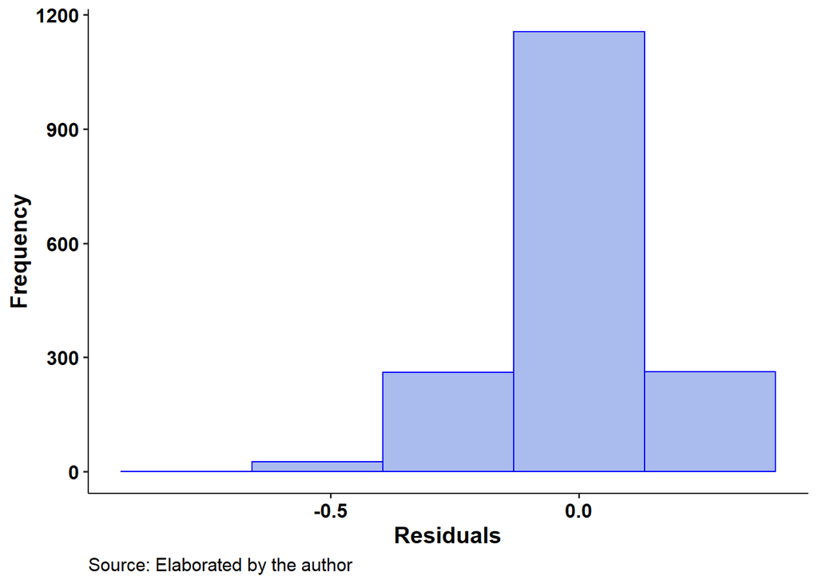

```r
model.df <- as.data.frame(residuals(model))
names(model.df) <- c("residuals")
g <- ggplot(data = model.df, aes(residuals)) +
  geom_histogram(fill="#aabbee",color = "blue",stat = "bin", bins = 5) +
  theme_pubr() + labs_pubr() + xlab("Residuals") + ylab("Frequency") +
  theme(plot.caption = element_text(hjust = 0)) +
  labs(caption = "Source: Elaborated by the author" )
g
```